# chapter5.Rmd

Johanna Räbinä

26 11 2020

# Report of exercise 5

During the last weeks I’ve noticed that through this course I’ve taken some steps forward with R: for example I manage to resolve some problems that occure during the exercises by reading R documentation or googling some examples. I also understand the code better and can do some minor adjustments to it when necessary. Obviously, there’s still so much to learn to become a more independent R user, but I’m on my way there (which I wasn’t so sure about before this course).

This week, the exercises felt pretty comprehensible and the interpretation of PCA was logical to me.

## Exploring the data (step 1)

First, I’ll access the necessary libraries and load the data. Then I’ll explore the dataset - all the variables and observations are in place. After this I’ll explore the distributions and relations of the variables.

```r
library(dplyr)
library(GGally)
```

```r
library(corrplot)
human <- read.csv("data/human.csv", row.names = 1)

dim(human)
```

```
## [1] 155   8
```

```r
head(human)
```

```
##              eduratio  labratio Edu.exp Life.exp   GNI Mat.mor Ado.BR Parl.rep
## Norway      1.0072389 0.8908297    17.5     81.6 64992       4    7.8     39.6
## Australia   0.9968288 0.8189415    20.2     82.4 42261       6   12.1     30.5
## Switzerland 0.9834369 0.8251001    15.8     83.0 56431       6    1.9     28.5
## Denmark     0.9886128 0.8840361    18.7     80.2 44025       5    5.1     38.0
## Netherlands 0.9690608 0.8286119    17.9     81.6 45435       6    6.2     36.9
## Germany     0.9927835 0.8072289    16.5     80.9 43919       7    3.8     36.9
```

```r
summary(human)
```

```
##     eduratio         labratio         Edu.exp         Life.exp
##  Min.   :0.1717   Min.   :0.1857   Min.   : 5.40   Min.   :49.00
##  1st Qu.:0.7264   1st Qu.:0.5984   1st Qu.:11.25   1st Qu.:66.30
##  Median :0.9375   Median :0.7535   Median :13.50   Median :74.20
##  Mean   :0.8529   Mean   :0.7074   Mean   :13.18   Mean   :71.65
##  3rd Qu.:0.9968   3rd Qu.:0.8535   3rd Qu.:15.20   3rd Qu.:77.25
##  Max.   :1.4967   Max.   :1.0380   Max.   :20.20   Max.   :83.50
##       GNI            Mat.mor           Ado.BR          Parl.rep
##  Min.   :   581   Min.   :   1.0   Min.   :  0.60   Min.   : 0.00
##  1st Qu.:  4198   1st Qu.:  11.5   1st Qu.: 12.65   1st Qu.:12.40
##  Median : 12040   Median :  49.0   Median : 33.60   Median :19.30
##  Mean   : 17628   Mean   : 149.1   Mean   : 47.16   Mean   :20.91
##  3rd Qu.: 24512   3rd Qu.: 190.0   3rd Qu.: 71.95   3rd Qu.:27.95
##  Max.   :123124   Max.   :1100.0   Max.   :204.80   Max.   :57.50
```

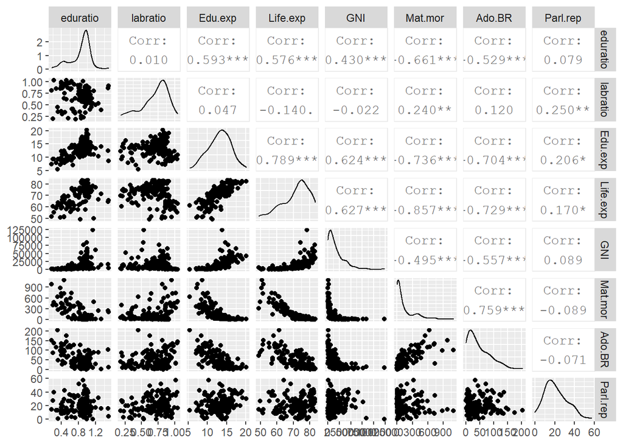

```r
ggpairs(human)
```

```r
cor_matrix_<-cor(human) %>% round(digits=2)
cor_matrix_
```

```
##          eduratio labratio Edu.exp Life.exp   GNI Mat.mor Ado.BR Parl.rep
## eduratio     1.00     0.01    0.59     0.58  0.43   -0.66  -0.53     0.08
## labratio     0.01     1.00    0.05    -0.14 -0.02    0.24   0.12     0.25
## Edu.exp      0.59     0.05    1.00     0.79  0.62   -0.74  -0.70     0.21
## Life.exp     0.58    -0.14    0.79     1.00  0.63   -0.86  -0.73     0.17
## GNI          0.43    -0.02    0.62     0.63  1.00   -0.50  -0.56     0.09
## Mat.mor     -0.66     0.24   -0.74    -0.86 -0.50    1.00   0.76    -0.09
## Ado.BR      -0.53     0.12   -0.70    -0.73 -0.56    0.76   1.00    -0.07
## Parl.rep     0.08     0.25    0.21     0.17  0.09   -0.09  -0.07     1.00
```

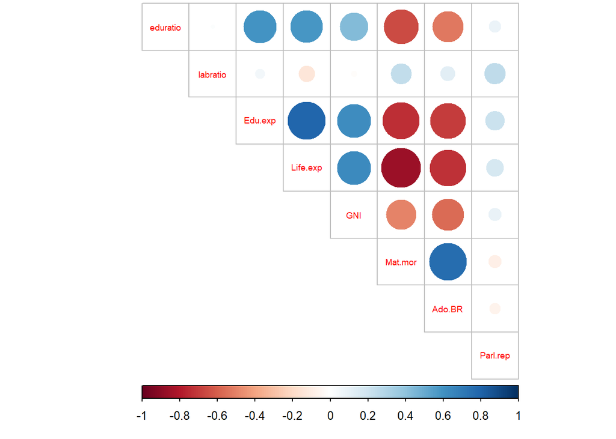

```r
corrplot(cor_matrix_, method="circle", type="upper", cl.pos="b",tl.pos="d",tl.cex=0.6)
```

### Distributions of the variables:

From summary I see that the variables are of very different scales. From ggpairs-picture I see that many of the variables are skewed:

- skewed to the lower end of the distribution: GNI, Mat.mor, Ado.BR, Parl.rep
- skewed to the upper end of the distribution: labratio, Life.exp
- not very skewed: eduratio, Edu.exp

### Relations between the variables:

From correlation matrix and corrplot I see that there are a lot of correlations between the variables. The strongest positive correlations are between:

- Ado.BR - Mar.mor
- Edu.exp - Life.exp

And the strongest negative correlations are between:

- Life.exp - Mat.mor
- Life.exp - Ado.BR
- Edu.exp - Mat.mor
- Edu.exp - Ado.BR

Variables *Parl.rep* and *labratio* don’t have very strong correlation with any of the other variables.

Next, I’ll move to the analysis part.

## PCA with non-standardized data (step 2)

```r
pca_human <- prcomp(human)
pca_human
```

```
## Standard deviations (1, .., p=8):
## [1] 1.854416e+04 1.855219e+02 2.518701e+01 1.145441e+01 3.766241e+00
## [6] 1.565912e+00 1.912052e-01 1.591112e-01
##
## Rotation (n x k) = (8 x 8):
##                    PC1           PC2           PC3           PC4           PC5
## eduratio -5.607472e-06  0.0006713951 -3.412027e-05 -2.736326e-04 -0.0022935252
## labratio  2.331945e-07 -0.0002819357  5.302884e-04 -4.692578e-03  0.0022190154
## Edu.exp  -9.562910e-05  0.0075529759  1.427664e-02 -3.313505e-02  0.1431180282
## Life.exp -2.815823e-04  0.0283150248  1.294971e-02 -6.752684e-02  0.9865644425
## GNI      -9.999832e-01 -0.0057723054 -5.156742e-04  4.932889e-05 -0.0001135863
## Mat.mor   5.655734e-03 -0.9916320120  1.260302e-01 -6.100534e-03  0.0266373214
## Ado.BR    1.233961e-03 -0.1255502723 -9.918113e-01  5.301595e-03  0.0188618600
## Parl.rep -5.526460e-05  0.0032317269 -7.398331e-03 -9.971232e-01 -0.0716401914
##                    PC6           PC7           PC8
## eduratio  2.180183e-02  6.998623e-01  7.139410e-01
## labratio  3.264423e-02  7.132267e-01 -7.001533e-01
## Edu.exp   9.882477e-01 -3.826887e-02  7.776451e-03
## Life.exp -1.453515e-01  5.380452e-03  2.281723e-03
## GNI      -2.711698e-05 -8.075191e-07 -1.176762e-06
## Mat.mor   1.695203e-03  1.355518e-04  8.371934e-04
## Ado.BR    1.273198e-02 -8.641234e-05 -1.707885e-04
## Parl.rep -2.309896e-02 -2.642548e-03  2.680113e-03
```

```r
summary(pca_human)
```

```
## Importance of components:
##                              PC1      PC2   PC3   PC4   PC5   PC6    PC7    PC8
## Standard deviation     1.854e+04 185.5219 25.19 11.45 3.766 1.566 0.1912 0.1591
## Proportion of Variance 9.999e-01   0.0001  0.00  0.00 0.000 0.000 0.0000 0.0000
## Cumulative Proportion  9.999e-01   1.0000  1.00  1.00 1.000 1.000 1.0000 1.0000
```

```r
s0 <- summary(pca_human)
s0
```

```
## Importance of components:
##                              PC1      PC2   PC3   PC4   PC5   PC6    PC7    PC8
## Standard deviation     1.854e+04 185.5219 25.19 11.45 3.766 1.566 0.1912 0.1591
## Proportion of Variance 9.999e-01   0.0001  0.00  0.00 0.000 0.000 0.0000 0.0000
## Cumulative Proportion  9.999e-01   1.0000  1.00  1.00 1.000 1.000 1.0000 1.0000
```

```r
pca_pr <- round(100*s0$importance[2, ], digits = 1)
pca_pr
```

```
## PC1 PC2 PC3 PC4 PC5 PC6 PC7 PC8
## 100   0   0   0   0   0   0   0
```

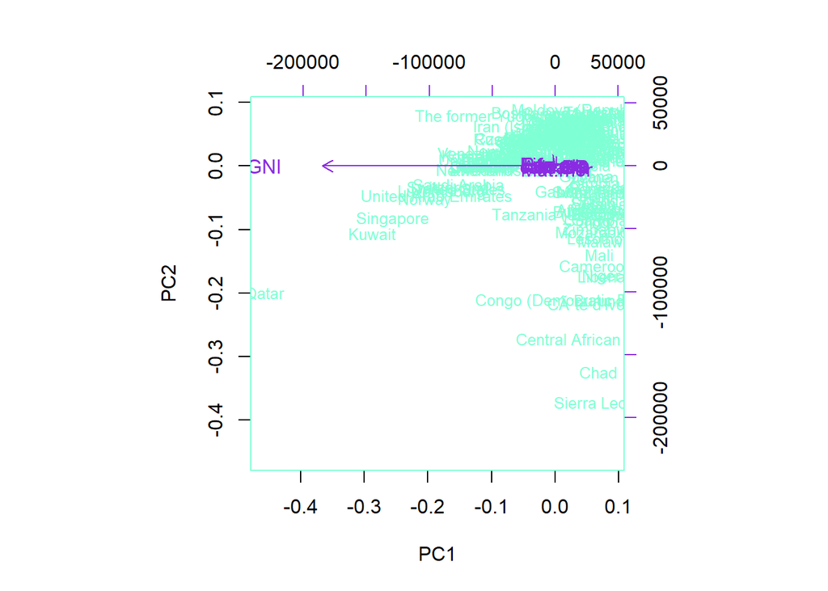

```r
pc_lab <- paste0(names(pca_pr), " (", pca_pr, "%)")
biplot(pca_human, choices = 1:2, cex = c(0.8,1), col = c("aquamarine", "blueviolet", xlab = pc_lab[1], ylab = pc_lab[2]))
```

## PCA with standardized data (step 3)

First, I’ll standardize the variables and check that the standardization went ok. Then I’ll conduct PCA with the standardized data and take the summary and see the percentages of variance captured by the model. After this I’ll draw a biplot with variance information on the axes.

```r
human_std <- scale(human)
summary(human_std)
```

```
##     eduratio          labratio          Edu.exp           Life.exp
##  Min.   :-2.8189   Min.   :-2.6247   Min.   :-2.7378   Min.   :-2.7188
##  1st Qu.:-0.5233   1st Qu.:-0.5484   1st Qu.:-0.6782   1st Qu.:-0.6425
##  Median : 0.3503   Median : 0.2316   Median : 0.1140   Median : 0.3056
##  Mean   : 0.0000   Mean   : 0.0000   Mean   : 0.0000   Mean   : 0.0000
##  3rd Qu.: 0.5958   3rd Qu.: 0.7350   3rd Qu.: 0.7126   3rd Qu.: 0.6717
##  Max.   : 2.6646   Max.   : 1.6632   Max.   : 2.4730   Max.   : 1.4218
##       GNI             Mat.mor            Ado.BR           Parl.rep
##  Min.   :-0.9193   Min.   :-0.6992   Min.   :-1.1325   Min.   :-1.8203
##  1st Qu.:-0.7243   1st Qu.:-0.6496   1st Qu.:-0.8394   1st Qu.:-0.7409
##  Median :-0.3013   Median :-0.4726   Median :-0.3298   Median :-0.1403
##  Mean   : 0.0000   Mean   : 0.0000   Mean   : 0.0000   Mean   : 0.0000
##  3rd Qu.: 0.3712   3rd Qu.: 0.1932   3rd Qu.: 0.6030   3rd Qu.: 0.6127
##  Max.   : 5.6890   Max.   : 4.4899   Max.   : 3.8344   Max.   : 3.1850
```

```r
pca_human_std <- prcomp(human_std)
pca_human_std
```

```
## Standard deviations (1, .., p=8):
## [1] 2.0708380 1.1397204 0.8750485 0.7788630 0.6619563 0.5363061 0.4589994
## [8] 0.3222406
##
## Rotation (n x k) = (8 x 8):
##                  PC1         PC2         PC3         PC4        PC5         PC6
## eduratio -0.35664370  0.03796058 -0.24223089  0.62678110 -0.5983585  0.17713316
## labratio  0.05457785  0.72432726 -0.58428770  0.06199424  0.2625067 -0.03500707
## Edu.exp  -0.42766720  0.13940571 -0.07340270 -0.07020294  0.1659678 -0.38606919
## Life.exp -0.44372240 -0.02530473  0.10991305 -0.05834819  0.1628935 -0.42242796
## GNI      -0.35048295  0.05060876 -0.20168779 -0.72727675 -0.4950306  0.11120305
## Mat.mor   0.43697098  0.14508727 -0.12522539 -0.25170614 -0.1800657  0.17370039
## Ado.BR    0.41126010  0.07708468  0.01968243  0.04986763 -0.4672068 -0.76056557
## Parl.rep -0.08438558  0.65136866  0.72506309  0.01396293 -0.1523699  0.13749772
##                  PC7         PC8
## eduratio  0.05773644  0.16459453
## labratio -0.22729927 -0.07304568
## Edu.exp   0.77962966 -0.05415984
## Life.exp -0.43406432  0.62737008
## GNI      -0.13711838 -0.16961173
## Mat.mor   0.35380306  0.72193946
## Ado.BR   -0.06897064 -0.14335186
## Parl.rep  0.00568387 -0.02306476
```

```r
s <- summary(pca_human_std)
s
```

```
## Importance of components:
##                           PC1    PC2     PC3     PC4     PC5     PC6     PC7
## Standard deviation     2.0708 1.1397 0.87505 0.77886 0.66196 0.53631 0.45900
## Proportion of Variance 0.5361 0.1624 0.09571 0.07583 0.05477 0.03595 0.02634
## Cumulative Proportion  0.5361 0.6984 0.79413 0.86996 0.92473 0.96069 0.98702
##                            PC8
## Standard deviation     0.32224
## Proportion of Variance 0.01298
## Cumulative Proportion  1.00000
```

```r
pca_std_pr <- round(100*s$importance[2, ], digits = 1)
pca_std_pr
```

```
##  PC1  PC2  PC3  PC4  PC5  PC6  PC7  PC8
## 53.6 16.2  9.6  7.6  5.5  3.6  2.6  1.3
```

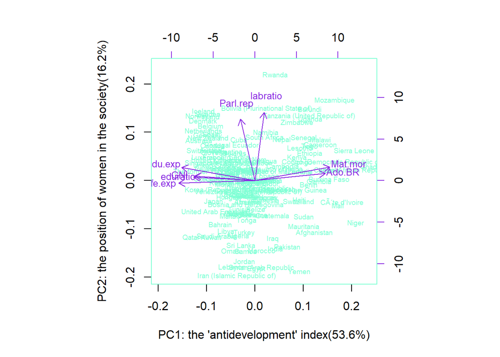

```r
pc_lab_std1 <- paste0("PC1: the 'antidevelopment' index", "(", pca_std_pr[1], "%)")

pc_lab_std2 <- paste0("PC2: the position of women in the society", "(", pca_std_pr[2], "%)")

biplot(pca_human_std, cex = c(0.6, 0.8), col = c("aquamarine", "blueviolet"), xlab = pc_lab_std1, ylab = pc_lab_std2)
```

Overall, I can see that the results of the two analysis differ very much, and below I will take a closer look on both analysis and explain where the difference comes from.

### Interpretation of the model with non-standardized data

With these non-standardized variables the analysis doesn’t seem to work very well. The first principal component captures practically all of the variability, and variable *GNI* correlates completely with that component. When I see the scales of the variables I see that *GNI* values are of a much larger scale than any of the other variables, and this is why it is weighted so much in the analysis. Conclusion: With the non-standardized variables PCA doesn’t serve its purpose: this analysis doesn’t squeeze up the information of many variables, it only shows the distribution of observations based on the largest-scale variable.

### Interpretation of the model with standardized data

PC1 captures ~54 % of the variability of the data, PC2 ~16 %, PC3 ~10% and PC4 ~8%. The number of components to include in the model is a tricky question, since there is no rule about which criteria should be applied. Using criteria that the total variance explained by the model should be something between 70-90 %, I would include 2 (almost 70 % of explained variance) 3 (79 %) or 4 (87 %) components. The two-component solution was quite easy to interpret, so that would pull on that side, but I am not sure if this is a relevant basis for the choice.

## Interpretation of the first two principal component dimensions with standardized data (Step 4)

From the biplot I see that the first component correlates strongly and positively with *adolescent birth rate* and *maternal mortality rate* and has strong negative correlations with *life expectancy*, *expected years of schooling*, *GNI* and *proportion of females vs. males receiving secondary education*. Thus, the first component seems to be somewhat general index for “antidevelopment” of countries: the more a country has points in this component, the less it is developed. The second principal component correlates with *proportion of females vs. males in the labour force* and *percetage of female representatives in parliament*, so it seems to indicate the position of women in the society: the more points a country has on this component, the more women get to participate in the societal actions (of course this is a simplification based on these variables). The variables are correlated with the components and each other as could be predicted from the initial correlations: *Parl.rep* and *labratio* didn’t correlate much with the other variables.

Let’s also take a look at how the countries are situated in the picture. In the upper left side of the picture are “the most developed and equal countries”, like many of the Northern countries. Respectively, in the bottom right side are the least developed and not equal countries like Mauritania, Afghanistan, Niger and Yemen. In the bottom part of the picture are those countries where women don’t get to participate to the society very much, and logically there are e.g. many Arabic countries. In the upper section of the picture there are countries in which women participate a lot in the society, and somewhat surprisingly there are many African countries (and not so surprisingly many Europian countries also).

## Tea dataset and MCA (step 5)

First, I’ll access the necessary libraries, select the columns that I find interesting, and then explore the distributions of the variables.

```r
library(FactoMineR)
```

```r
library(ggplot2)
library(dplyr)
library(tidyr)
data(tea)
str(tea)
```

```
## 'data.frame':    300 obs. of  36 variables:
##  $ breakfast       : Factor w/ 2 levels "breakfast","Not.breakfast": 1 1 2 2 1 2 1 2 1 1 ...
##  $ tea.time        : Factor w/ 2 levels "Not.tea time",..: 1 1 2 1 1 1 2 2 2 1 ...
##  $ evening         : Factor w/ 2 levels "evening","Not.evening": 2 2 1 2 1 2 2 1 2 1 ...
##  $ lunch           : Factor w/ 2 levels "lunch","Not.lunch": 2 2 2 2 2 2 2 2 2 2 ...
##  $ dinner          : Factor w/ 2 levels "dinner","Not.dinner": 2 2 1 1 2 1 2 2 2 2 ...
##  $ always          : Factor w/ 2 levels "always","Not.always": 2 2 2 2 1 2 2 2 2 2 ...
##  $ home            : Factor w/ 2 levels "home","Not.home": 1 1 1 1 1 1 1 1 1 1 ...
##  $ work            : Factor w/ 2 levels "Not.work","work": 1 1 2 1 1 1 1 1 1 1 ...
##  $ tearoom         : Factor w/ 2 levels "Not.tearoom",..: 1 1 1 1 1 1 1 1 1 2 ...
##  $ friends         : Factor w/ 2 levels "friends","Not.friends": 2 2 1 2 2 2 1 2 2 2 ...
##  $ resto           : Factor w/ 2 levels "Not.resto","resto": 1 1 2 1 1 1 1 1 1 1 ...
##  $ pub             : Factor w/ 2 levels "Not.pub","pub": 1 1 1 1 1 1 1 1 1 1 ...
##  $ Tea             : Factor w/ 3 levels "black","Earl Grey",..: 1 1 2 2 2 2 2 1 2 1 ...
##  $ How             : Factor w/ 4 levels "alone","lemon",..: 1 3 1 1 1 1 1 3 3 1 ...
```

[output cut: 22 more lines]

```r
keep_columns <- c("Tea", "How", "breakfast", "work", "where", "sex")
tea_time <- dplyr::select(tea, one_of(keep_columns))
str(tea_time)
```

```
## 'data.frame':    300 obs. of  6 variables:
##  $ Tea      : Factor w/ 3 levels "black","Earl Grey",..: 1 1 2 2 2 2 2 1 2 1 ...
##  $ How      : Factor w/ 4 levels "alone","lemon",..: 1 3 1 1 1 1 1 3 3 1 ...
##  $ breakfast: Factor w/ 2 levels "breakfast","Not.breakfast": 1 1 2 2 1 2 1 2 1 1 ...
##  $ work     : Factor w/ 2 levels "Not.work","work": 1 1 2 1 1 1 1 1 1 1 ...
##  $ where    : Factor w/ 3 levels "chain store",..: 1 1 1 1 1 1 1 1 2 2 ...
##  $ sex      : Factor w/ 2 levels "F","M": 2 1 1 2 2 2 2 1 2 2 ...
```

```r
dim(tea_time)
```

```
## [1] 300   6
```

```r
summary(tea_time)
```

```
##         Tea         How              breakfast         work
##  black    : 74   alone:195   breakfast    :144   Not.work:213
##  Earl Grey:193   lemon: 33   Not.breakfast:156   work    : 87
##  green    : 33   milk : 63
##                  other:  9
##                   where     sex
##  chain store         :192   F:178
##  chain store+tea shop: 78   M:122
##  tea shop            : 30
##
```

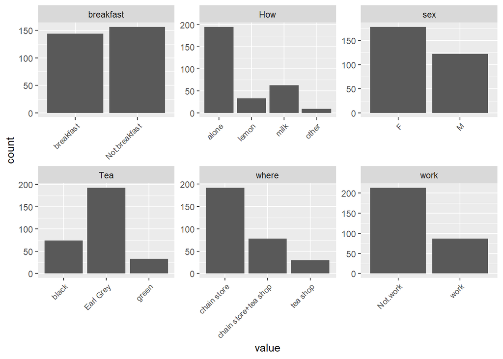

```r
gather(tea_time) %>% ggplot(aes(value)) + facet_wrap("key", scales = "free") + geom_bar() + theme(axis.text.x = element_text(angle = 45, hjust = 1, size = 8))
```

### Exploration of the variables:

There are now six variables and 300 observations (people). All the variables are categorical.

My comments on the distributions of the variables:

- breakfast: In this sample, there are almost as many people that drink tea in the morning as those who don’t.
- How: Most of the people in this sample drink their tea without add-ons. The most popular add-on is milk.
- sex: There are a bit more women than men in this sample.
- Tea: The most popular tea quality in this sample is Earl Grey.
- where: The most of the people in this sample by their teas from chain stores.
- work: Most of the people in this sample don’t drink tea at work.

### MCA

Next, I’ll perform MCA for the subset of the tea-data, see the summary of the model and then draw biplots with first the variables and then the individuals.

```r
mca <- MCA(tea_time, graph = FALSE)
summary(mca)
```

```
##
## Call:
## MCA(X = tea_time, graph = FALSE)
##
##
## Eigenvalues
##                        Dim.1   Dim.2   Dim.3   Dim.4   Dim.5   Dim.6   Dim.7
## Variance               0.253   0.216   0.202   0.191   0.151   0.145   0.137
## % of var.             15.161  12.982  12.143  11.445   9.074   8.675   8.248
## Cumulative % of var.  15.161  28.143  40.287  51.731  60.805  69.480  77.727
##                        Dim.8   Dim.9  Dim.10
## Variance               0.133   0.123   0.115
## % of var.              8.004   7.381   6.888
## Cumulative % of var.  85.731  93.112 100.000
##
## Individuals (the 10 first)
##                  Dim.1    ctr   cos2    Dim.2    ctr   cos2    Dim.3    ctr
## 1             | -0.192  0.048  0.031 |  0.600  0.555  0.304 | -0.492  0.399
## 2             |  0.265  0.093  0.044 |  0.561  0.484  0.197 | -0.671  0.741
## 3             |  0.086  0.010  0.008 | -0.760  0.890  0.607 | -0.036  0.002
## 4             | -0.463  0.283  0.290 | -0.161  0.040  0.035 | -0.136  0.031
## 5             | -0.173  0.040  0.039 |  0.052  0.004  0.004 | -0.327  0.176
## 6             | -0.463  0.283  0.290 | -0.161  0.040  0.035 | -0.136  0.031
## 7             | -0.173  0.040  0.039 |  0.052  0.004  0.004 | -0.327  0.176
## 8             | -0.025  0.001  0.000 |  0.348  0.186  0.077 | -0.481  0.380
## 9             |  0.518  0.354  0.159 |  0.545  0.457  0.176 | -0.122  0.025
## 10            |  0.206  0.056  0.027 |  0.711  0.779  0.323 | -0.112  0.021
##                 cos2
## 1              0.205 |
## 2              0.283 |
## 3              0.001 |
## 4              0.025 |
## 5              0.139 |
## 6              0.025 |
## 7              0.139 |
## 8              0.148 |
## 9              0.009 |
## 10             0.008 |
##
## Categories (the 10 first)
```

[output cut: 16 more lines]

```
## lemon           1.172 |   2.104  40.107   0.547  12.792 |
## milk            6.432 |  -0.622   6.696   0.103  -5.547 |
## other           5.118 |  -0.146   0.053   0.001  -0.445 |
## breakfast       5.135 |  -0.267   2.820   0.066  -4.437 |
## Not.breakfast  -5.135 |   0.247   2.603   0.066   4.437 |
## Not.work        3.906 |  -0.081   0.385   0.016  -2.197 |
##
## Categorical variables (eta2)
##                 Dim.1 Dim.2 Dim.3
## Tea           | 0.337 0.430 0.044 |
## How           | 0.256 0.275 0.583 |
## breakfast     | 0.191 0.088 0.066 |
## work          | 0.280 0.051 0.016 |
## where         | 0.393 0.121 0.505 |
## sex           | 0.058 0.333 0.000 |
```

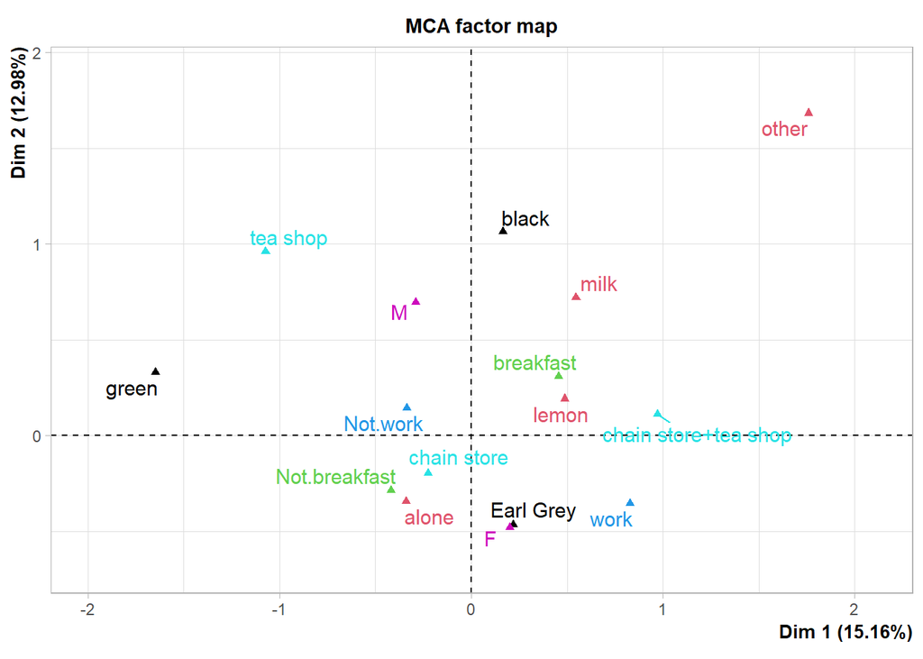

```r
plot(mca, invisible=c("ind"), habillage = "quali")
```

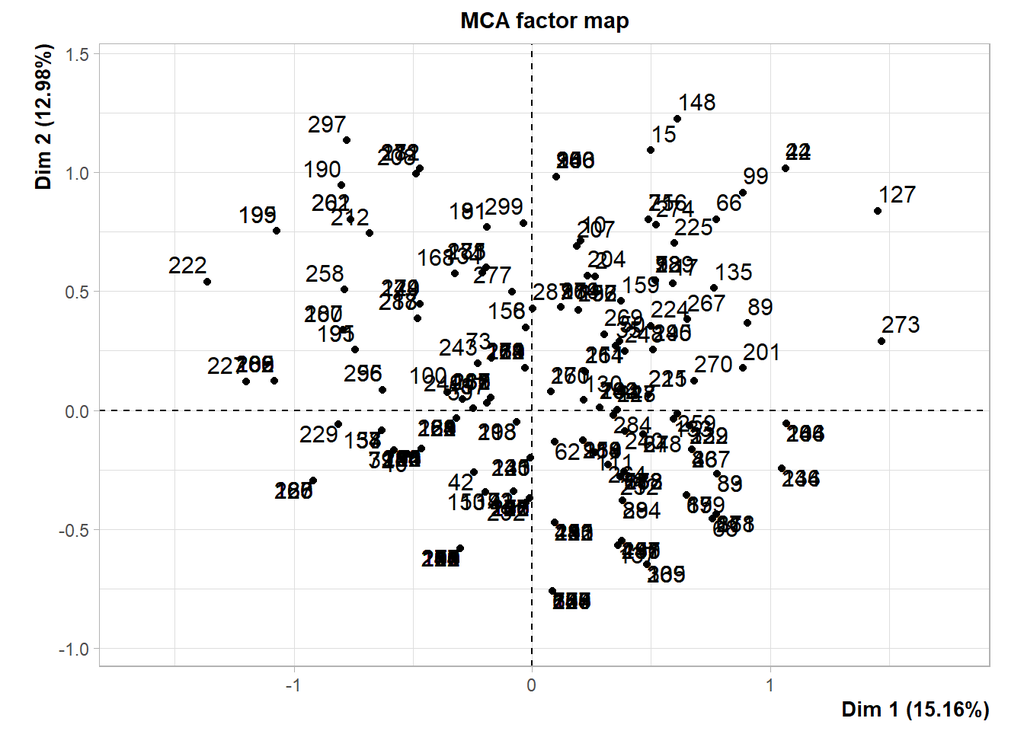

```r
plot(mca, invisible=c("var"))
```

### Interpretation of the model:

I find it difficult to make any “overall” interpretation from this model or plots. This might be because none of the dimensions explains a large proportion of the variability in the data - the first dimension explains only ~15 % and the second ~13 %, together ~28 %. From the biplot of the variables I see that e.g. drinking green tea and buying teas from teashop are related. Men seem to consume more black tea and women earl grey. Those who buy teas from chain stores, don’t usually drink it on breakfast, and mostly drink their tea alone. The biplot of individuals doesn’t show any specific groups (the individuals are pretty equally distributed around the two dimensions) and thus no interpretation can be made (or at least I can’t figure out one). Maybe the overall conclusion is that this MCA-analysis didn’t help much in squeezing up the information of these six variables since the proportion of variance explained by first six dimensions is only ~69 %.